# Seminar: Statistics for Data Science: Group C

Personal Agency vs. Environmental Determinism in Academic Success

Author

Dmytro Tupkalenko (89252101), …

Published

May 2026

## Setup

```r
library(tidyverse)
library(naniar)
library(Hmisc)
library(kableExtra)
library(GGally)
library(gt)
library(reshape2)
library(htmltools)
library(patchwork)
library(psych)
library(viridis)
library(pheatmap)
library(RColorBrewer)
library(broom)

VIR_PAL = "B"
theme_set(theme_minimal(base_size = 11))
setwd("./")
```

## Research Question & Statistical Analysis Plan

### Aim

General Formulation — Personal Agency vs. Environmental Determinism: To what extent do student-driven behavioral choices predict academic success in Portuguese and Mathematics compared to structural and environmental constraints?

Concrete Formulation —

1. Descriptive analysis: what variables accounting for behavioral choices and environmental constraints are associated with the final grade in Portuguese and Mathematics and how strong are these associations.
2. Predictive analysis: which of the two models, where the first is fitted only on structural and environmental constraints and the second is fitted on both the constraints and the behavioral choices has bigger predictive power.

### Target Population

Students aged between 15 and 22 that are enrolled in Mathematics and Portuguese language courses at two distinct schools (Gabriel Pereira and Mousinho da Silveira).

### Variables

Based on our research question, we have selected the following variables from both of the datasets for Mathematics and Portuguese (the same variables are used in both datasets):

**Outcome:**

- `G3` - final grade (numeric: from 0 to 20, output target).
  - *Motivation:* This is the definitive measure of academic success for our analysis.

**General:**

- `sex` - student’s sex (binary: “F” - female or “M” - male).
  - *Motivation:* Included as a standard demographic control.
- `age` - student’s age (numeric: from 15 to 22).
  - *Motivation:* Included as a standard demographic control.
- `school` - student’s school (binary: “GP” - Gabriel Pereira or “MS” - Mousinho da Silveira).
  - *Motivation:* Included as an environmental control.

**Behavioral Predictors (Choices and Habits):**

- `goout` - going out with friends (ordinal: from 1 - very low to 5 - very high).
  - *Motivation:* Represents a student-driven behavioral choice regarding time allocation and social priorities.
- `activities` - extra-curricular activities (binary: yes or no).
  - *Motivation:* Reflects proactive personal agency in seeking non-academic additions and skill-building.
- `Dalc*` - workday alcohol consumption (ordinal: from 1 - very low to 5 - very high).
  - *Motivation:* Captures a potentially detrimental personal lifestyle choice that directly impacts daily cognitive function and academic readiness.
- `Walc*` - weekend alcohol consumption (ordinal: from 1 - very low to 5 - very high).
  - *Motivation:* Similar to `Dalc`, this isolates weekend social choices that might compete with weekend study or recovery time.
- `studytime` - weekly study time (ordinal: 1 - <2 hours, 2 - 2 to 5 hours, 3 - 5 to 10 hours, or 4 - >10 hours).
  - *Motivation:* The most direct proxy for personal agency, effort, and academic discipline.
- `romantic` - with a romantic relationship (binary: yes or no).
  - *Motivation:* Represents a personal commitment that requires an allocation of emotional energy and time, potentially competing with academic focus.

**Structural/Environmental Predictors (Background and Constraints):**

- `address` - student’s home address type (binary: “U” - urban or “R” - rural).
  - *Motivation:* Captures geographic structural constraints, such as access to urban resources, libraries, or potential rural isolation.
- `famsize` - family size (binary: “LE3” - less or equal to 3 or “GT3” - greater than 3).
  - *Motivation:* An environmental factor that may influence the home study environment.
- `Pstatus` - parent’s cohabitation status (binary: “T” - living together or “A” - apart).
  - *Motivation:* Reflects foundational family structure and potential home-life stability, which is entirely outside the student’s control.
- `Medu**` - mother’s education (ordinal: 0 - none, 1 - primary education (4th grade), 2 – 5th to 9th grade, 3 – secondary education or 4 – higher education).
  - *Motivation:* A proxy for socioeconomic status and inherited cultural capital within the home environment.
- `Fedu**` - father’s education (ordinal: 0 - none, 1 - primary education (4th grade), 2 – 5th to 9th grade, 3 – secondary education or 4 – higher education).
  - *Motivation:* Complements mother’s education to fully capture the structural intellectual and socioeconomic background provided by the family.
- `traveltime` - home to school travel time (ordinal: 1 - <15 min., 2 - 15 to 30 min., 3 - 30 min. to 1 hour, or 4 - >1 hour).
  - *Motivation:* A physical, environmental constraint that dictates how much “dead time” a student experiences, limiting their available hours for study or rest.
- `internet` - internet access at home (binary: yes or no)
  - *Motivation:* Defines access to online-based study materials.
- `health` - current health status (ordinal: from 1 - very bad to 5 - very good).
  - *Motivation:* An inherent biological/environmental constraint that affects a student’s baseline capacity to perform, regardless of their willpower or choices.

Note that variables marked with * and ** respectively are hypothesized to be strongly associated, but are still included in the initial set with the possibility to be ruled out after Initial Data Analysis.

### Excluded Variables and Rationale

Remaining variables available in the broader dataset were intentionally excluded to maintain a sharp focus on testing our core hypothesis. Past academic performance metrics (`G1`, `G2`, and past `failures`) were removed; including these would artificially overwhelm model accuracy. Additionally, family metrics (like `Mjob`, `Fjob`, and `guardian`) were excluded because we concluded that the proxy for sociometric status (Fedu and Medu) were enough and because Mjob and Fjob are just factors with type of the job, they do not provide any insight in e.g. family capital or other measurable metric. Variables (`schoolsup`, `famsup`, `paid`, `nursery`, `higher`,`freetime` `famrel`) were omitted because we could not strictly classify them into one of the classes, e.g. attending paid lessons is based on desire of the student or parents.

### Statistical Approach

To address our research questions, we will use multiple linear regression. We will fit **four models in total** - two for the Mathematics dataset and two for the Portuguese dataset.

#### Model Specifications

For each subject, we define two nested models:

1. **Structural Model (Base):** This model includes only the inherent demographic controls and constraints.
   $$G3 = \beta_0 + \sum_{j \in \text{General}} \beta_j X_j + \sum_{k \in \text{Structural}} \beta_k X_k + \epsilon$$
2. **Full Model (Agency + Environment):** This model adds behavioral predictors to the base model to measure the added value of personal agency.
   $$G3 = \beta_0 + \sum_{j \in \text{General}} \beta_j X_j + \sum_{k \in \text{Structural}} \beta_k X_k + \sum_{l \in \text{Behavioral}} \beta_l X_l + \epsilon$$

#### Evaluation Framework

We will evaluate these models through two lenses:

- Descriptive Analysis & Interpretation: Using the Full Model, we will analyze and interpet the coefficients to determine which specific behaviors or structural factors hold the most weight.
- Model Comparison & Predictive Power: To determine if adding “Personal Agency” variables significantly improves our ability to predict academic success, we will compare the Structural and Full models using diagnostic plots and three metrics:
  - AIC (Akaike Information Criterion): To assess model fit.
  - RMSE (Root Mean Square Error), MAE (Mean Absolute Error): To provide measures of how close predictions are to actual grades.

### Handling Ordinal Factors and Numeric Variables

Ordinal predictors are encoded in two different ways.

`Medu`, `Fedu`, `studytime` and `traveltime` are kept as ordered factors with successive difference contrasts. For parental education, the categories represent qualitatively distinct thresholds (e.g., no education vs. primary is a fundamentally different jump than secondary vs. higher), and assuming equal spacing between levels is not justified. For studytime and traveltime, the categories represent non-uniform time brackets, and a linear encoding would impose an arbitrary metric on a coarsely measured constraint.

The remaining ordinal variables - `goout`, ‘Dalc’, `Walc`, and `health` - are treated as numeric. These are all symmetric 5-point Likert-style scales. Treating each as a single numeric predictor is also motivated practically by sample size: 370 (reduced to in IDA 327 observations). Encoding each Likert variable as a factor would consume an additional 8–10, which we cannot afford with this data.

Age is mean-centered so that the intercept is interpretable as the predicted grade for a student at the average age of the sample.

## Data Management

### Import

```r
d_mat = read.table("data/student-mat.csv", sep = ";", header = TRUE)
d_por = read.table("data/student-por.csv", sep = ";", header = TRUE)

cat("Number of students of Mathematics:", nrow(d_mat), "\n")
```

```
Number of students of Mathematics: 395
```

```r
cat("Number of students of Portuguese:", nrow(d_por), "\n")
```

```
Number of students of Portuguese: 649
```

### Merge

We work on both Mathematics and Portuguese - so we merged them.

```r
# NOTE: we used bigger set of variables than in the description of the
# seminar,because we saw that in the case of using the smaller set, we get
# non-consistent rows, so two rows in mat and por with the same signature
# gave different responses to e.g. activities
d_combined = merge(d_mat, d_por,
                   by = c("school", "sex", "age", "address", "famsize",
                          "Pstatus", "Medu", "Fedu", "Mjob", "Fjob",
                          "reason", "guardian", "traveltime", "studytime",
                          "activities", "nursery", "higher", "internet",
                          "romantic", "famrel", "freetime", "goout",
                          "Dalc", "Walc", "health"),
                   suffixes = c(".mat", ".por"))

cat("Number of overlapping students:", nrow(d_combined), "\n")
```

```
Number of overlapping students: 370
```

### Variable Cleaning & Recoding

```r
# Binary factors
binary_map = list(
  school = list(
    lv = c("GP", "MS"),
    lb = c("0 - Gabriel Pereira", "1 - Mousinho da Silveira")
  ),
  sex = list(
    lv = c("F", "M"),
    lb = c("0 - Female", "1 - Male")
  ),
  address = list(
    lv = c("U", "R"),
    lb = c("0 - Urban", "1 - Rural")
  ),
  famsize = list(
    lv = c("LE3", "GT3"),
    lb = c("0 - <=3 members", "1 - >3 members")
  ),
  Pstatus = list(
    lv = c("A", "T"),
    lb = c("0 - Apart", "1 - Living together")
  ),
  activities = list(
    lv = c("no", "yes"),
    lb = c("0 - No", "1 - Yes")
  ),
  romantic = list(
    lv = c("no", "yes"),
    lb = c("0 - No", "1 - Yes")
  ),
  internet = list(
    lv = c("no", "yes"),
    lb = c("0 - No", "1 - Yes")
  )
)

for (v in names(binary_map)) {
  d_combined[[v]] = factor(
    d_combined[[v]],
    levels = binary_map[[v]]$lv,
    labels = binary_map[[v]]$lb
  )
}

# Ordered factors
edu_levels = c(
  "0 - None",
  "1 - Primary (4th grade)",
  "2 - 5th-9th grade",
  "3 - Secondary",
  "4 - Higher education"
)

d_combined$Medu = factor(
  d_combined$Medu,
  levels = 0:4,
  labels = edu_levels,
  ordered = TRUE
)

d_combined$Fedu = factor(
  d_combined$Fedu,
  levels = 0:4,
  labels = edu_levels,
  ordered = TRUE
)

d_combined$traveltime = factor(
  d_combined$traveltime,
  levels = 1:4,
  labels = c(
    "1 - <15 min",
    "2 - 15-30 min",
    "3 - 30 min-1 h",
    "4 - >1 h"
  ),
  ordered = TRUE
)

d_combined$studytime = factor(
  d_combined$studytime,
  levels = 1:4,
  labels = c(
    "1 - <2 h",
    "2 - 2-5 h",
    "3 - 5-10 h",
    "4 - >10 h"
  ),
  ordered = TRUE
)

# Define variable groups and subset to analytic datasets
general_vars  = c("school", "sex", "age")
behavioural_vars = c("goout", "activities", "Dalc",
                     "Walc", "studytime", "romantic")
structural_vars = c("address", "famsize", "Pstatus",
                    "Medu", "Fedu", "traveltime", "internet", "health")

# List of all ordinal variables that need incremental coding
ordinal_vars = c("Medu", "Fedu", "traveltime", "studytime")

# Apply Successive Difference Contrasts
for (v in ordinal_vars) {
  num_levels = length(levels(d_combined[[v]]))
  contrasts(d_combined[[v]]) = MASS::contr.sdif(num_levels)
}

prepare_subject_data = function(df, subject_suffix) {
  shared_cols = c(general_vars, behavioural_vars, structural_vars)
  df_sub = df[, c(shared_cols, paste0("G3", subject_suffix))]
  colnames(df_sub) = gsub(subject_suffix, "", colnames(df_sub), fixed = TRUE)
  return(df_sub)
}

d_mat_analysis = prepare_subject_data(d_combined, ".mat")
d_por_analysis = prepare_subject_data(d_combined, ".por")
```

## Initial Data Analysis

### IDA Screening: Missing Values

```r
shared_vars_ida = setdiff(names(d_mat_analysis), "G3")
d_unified_ida = d_mat_analysis[, shared_vars_ida]
d_unified_ida$G3_Math = d_mat_analysis$G3
d_unified_ida$G3_Por  = d_por_analysis$G3

d_unified_ida |>
  miss_var_summary() |>
  gt() |>
  tab_header(
    title = "Missing Value Summary",
    subtitle = "Predictor variables are shared across subjects;
    G3 shown separately per subject")
```

Missing Value Summary

Predictor variables are shared across subjects; G3 shown separately per subject

| variable | n_miss | pct_miss |
| --- | --- | --- |
| school | 0 | 0 |
| sex | 0 | 0 |
| age | 0 | 0 |
| goout | 0 | 0 |
| activities | 0 | 0 |
| Dalc | 0 | 0 |
| Walc | 0 | 0 |
| studytime | 0 | 0 |
| romantic | 0 | 0 |
| address | 0 | 0 |
| famsize | 0 | 0 |
| Pstatus | 0 | 0 |
| Medu | 0 | 0 |
| Fedu | 0 | 0 |
| traveltime | 0 | 0 |
| internet | 0 | 0 |
| health | 0 | 0 |
| G3_Math | 0 | 0 |
| G3_Por | 0 | 0 |

There are no NAs in this dataset.

#### Zero-values (e.g. None in education)

These are valid encodings, but they are special compared to other values - so we needed to look closer at them.

```r
zero_summary = data.frame(
  Variable = c("Medu = None", "Fedu = None",
                "G3 = 0 (Math)", "G3 = 0 (Portuguese)"),
  N = c(sum(d_mat_analysis$Medu == "0 - None"),
        sum(d_mat_analysis$Fedu == "0 - None"),
        sum(d_mat_analysis$G3 == 0),
        sum(d_por_analysis$G3 == 0)))

zero_summary |>
  gt() |>
  tab_header(title = "Zero / Baseline Value Counts",
             subtitle = "Medu & Fedu: parents with no education;
             G3: students scoring 0") |>
  cols_label(Variable = "Variable", N = "n")
```

Zero / Baseline Value Counts

Medu & Fedu: parents with no education; G3: students scoring 0

| Variable | n |
| --- | --- |
| Medu = None | 3 |
| Fedu = None | 2 |
| G3 = 0 (Math) | 35 |
| G3 = 0 (Portuguese) | 5 |

The first observation we could make is that for Medu = None and Fedu = None looking at the records, we could not understand whether these really correspond to not having education or they encode something else. Given that the presence of both is very small in the sample, which would even if the encodings are truthful not produce meaningful results in the model, we decided to exclude these records.

```r
d_combined = d_combined |>
  filter(Medu != "0 - None", Fedu != "0 - None")

d_combined$Medu = droplevels(d_combined$Medu)
d_combined$Fedu = droplevels(d_combined$Fedu)

contrasts(d_combined$Medu) = MASS::contr.sdif(length(levels(d_combined$Medu)))
contrasts(d_combined$Fedu) = MASS::contr.sdif(length(levels(d_combined$Fedu)))

cat("Observations after exclusion:", nrow(d_combined), "\n")
```

```
Observations after exclusion: 365
```

The second observation is for G3 being 0, there is no specification in student.txt so we were not sure what is the meaning. We supposed that this corresponds to dropouts from the course, which if true would largely inflate our models; because we wanted to focus on the difference in final grades not whether the student finishes the course. To check the assumption that this corresponds to dropouts, we summarized these cases below.

```r
# Pull G1, G2 from d_combined for analytic dataset students
g_mat = d_combined |> select(G1 = G1.mat, G2 = G2.mat, G3 = G3.mat)
g_por = d_combined |> select(G1 = G1.por, G2 = G2.por, G3 = G3.por)

g_mat |> filter(G3 == 0) |> as_tibble() |> print(n = Inf)
```

```
# A tibble: 35 × 3
      G1    G2    G3
   <int> <int> <int>
 1    12     0     0
 2     8     0     0
 3     6     7     0
 4    11     0     0
 5     4     0     0
 6     8     7     0
 7     6     7     0
 8     9     8     0
 9     6     5     0
10     7     8     0
11    10     9     0
12     6     0     0
```

[output cut: 23 more lines]

```r
g_por |> filter(G3 == 0) |> as_tibble() |> print(n = Inf)
```

```
# A tibble: 5 × 3
     G1    G2    G3
  <int> <int> <int>
1    11     9     0
2     7     5     0
3     7     7     0
4     7     7     0
5     5     8     0
```

```r
# Predictor means: G3=0 vs G3>0
make_zero_summary = function(df, subject) {
  df |>
    mutate(zero_g3 = ifelse(G3 == 0, "G3 = 0", "G3 > 0")) |>
    group_by(zero_g3) |>
    summarise(n = n(), mean_age = mean(age),
              mean_studytime = mean(as.numeric(studytime)),
              mean_goout = mean(as.numeric(goout)),
              mean_Dalc = mean(as.numeric(Dalc)),
              mean_Walc = mean(as.numeric(Walc)),
              mean_Medu = mean(as.numeric(Medu)),
              mean_Fedu = mean(as.numeric(Fedu))) |> gt() |>
    tab_header(title =
                 paste("Predictor Means: G3 = 0 vs G3 > 0 —", subject)) |>
    fmt_number(columns = where(is.double), decimals = 2)
}

make_zero_summary(d_mat_analysis, "Mathematics")
```

Predictor Means: G3 = 0 vs G3 > 0 — Mathematics

| zero_g3 | n | mean_age | mean_studytime | mean_goout | mean_Dalc | mean_Walc | mean_Medu | mean_Fedu |
| --- | --- | --- | --- | --- | --- | --- | --- | --- |
| G3 = 0 | 35 | 17.03 | 2.03 | 3.17 | 1.31 | 1.86 | 3.40 | 3.31 |
| G3 > 0 | 335 | 16.53 | 2.04 | 3.11 | 1.50 | 2.34 | 3.84 | 3.58 |

```r
make_zero_summary(d_por_analysis, "Portuguese")
```

Predictor Means: G3 = 0 vs G3 > 0 — Portuguese

| zero_g3 | n | mean_age | mean_studytime | mean_goout | mean_Dalc | mean_Walc | mean_Medu | mean_Fedu |
| --- | --- | --- | --- | --- | --- | --- | --- | --- |
| G3 = 0 | 5 | 18.20 | 1.20 | 3.00 | 2.40 | 3.20 | 3.40 | 2.80 |
| G3 > 0 | 365 | 16.55 | 2.05 | 3.12 | 1.47 | 2.28 | 3.81 | 3.57 |

First, in the Mathematics dataset, we observed that a subset of students with a final grade of zero (G3 = 0) also lack recorded grades for the second period (G2). Additionally, among their observable characteristics there is nothing indicating that these are some special group of students - there are differences especially among Portuguese students; but they are just other indicators that these students are dropouts (e.g. higher alcohol consumption - which is the characteristic that, we think, is generally agreed to be associated with not finishing some duty -> dropping out). So, these pattern suggests that these cases most likely correspond to students who dropped out. As we discussed before, keeping them would distort the analysis, so, we excluded these observations.

```r
n_before_sym = nrow(d_combined)

d_combined = d_combined |>
  filter(G3.mat > 0, G3.por > 0)

n_after_sym = nrow(d_combined)

cat("Observations after (G3 > 0 in both):", n_after_sym, "\n")
```

```
Observations after (G3 > 0 in both): 327
```

Since we excluded the students from the combined datasets, we needed to regenerate the analytic datasets with excluded observations.

```r
d_mat_analysis = prepare_subject_data(d_combined, ".mat")
d_por_analysis = prepare_subject_data(d_combined, ".por")
```

### IDA Screening: Univariate Descriptions

#### Continuous Variables

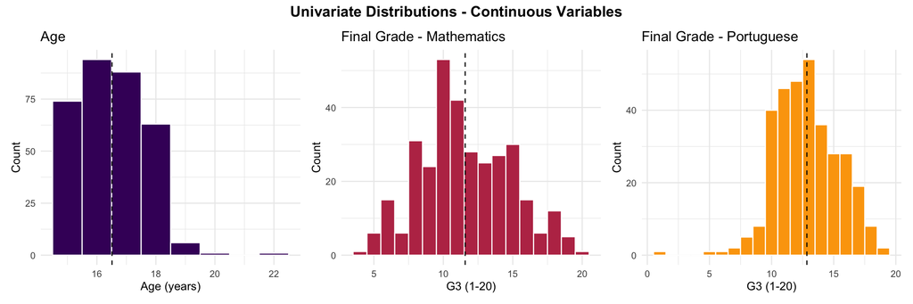

```r
p_age = ggplot(d_mat_analysis, aes(x = age)) +
  geom_histogram(binwidth = 1,
                 fill = viridis(1, option = VIR_PAL, begin = 0.2),
                 colour = "white") +
  geom_vline(xintercept = mean(d_mat_analysis$age), linetype = "dashed") +
  labs(title = "Age", x = "Age (years)", y = "Count")

p_g3_mat = ggplot(d_mat_analysis, aes(x = G3)) +
  geom_histogram(binwidth = 1,
                 fill = viridis(1, option = VIR_PAL, begin = 0.5),
                 colour = "white") +
  geom_vline(xintercept = mean(d_mat_analysis$G3), linetype = "dashed") +
  labs(title = "Final Grade - Mathematics", x = "G3 (1-20)", y = "Count")

p_g3_por = ggplot(d_por_analysis, aes(x = G3)) +
  geom_histogram(binwidth = 1,
                 fill = viridis(1, option = VIR_PAL, begin = 0.8),
                 colour = "white") +
  geom_vline(xintercept = mean(d_por_analysis$G3), linetype = "dashed") +
  labs(title = "Final Grade - Portuguese", x = "G3 (1-20)", y = "Count")

(p_age | p_g3_mat | p_g3_por) +
  plot_annotation(
    title    = "Univariate Distributions - Continuous Variables",
    theme    = theme(plot.title = element_text(size = 14,
                                               face = "bold", hjust = 0.5)))
```

```r
cont_df = data.frame(Age = d_mat_analysis$age, G3_Math = d_mat_analysis$G3,
                     G3_Portuguese = d_por_analysis$G3)

s_cont = Hmisc::describe(cont_df, digits = 1)
attr(s_cont, "descript") = "Continuous variables - overall characteristics"
Hmisc::html(s_cont)
```

Continuous variables - overall characteristics  
3 Variables 327 Observations

Age

| n | missing | distinct | Info | Mean | pMedian | Gmd |
| --- | --- | --- | --- | --- | --- | --- |
| 327 | 0 | 7 | 0.938 | 17 | 16 | 1 |

```
 Value         15    16    17    18    19    20    22
 Frequency     74    94    88    63     6     1     1
 Proportion 0.226 0.287 0.269 0.193 0.018 0.003 0.003
```

G3_Math

| n | missing | distinct | Info | Mean | pMedian | Gmd | .05 | .10 | .25 | .50 | .75 | .90 | .95 |
| --- | --- | --- | --- | --- | --- | --- | --- | --- | --- | --- | --- | --- | --- |
| 327 | 0 | 17 | 0.99 | 12 | 12 | 4 | 6 | 8 | 9 | 11 | 14 | 16 | 18 |

```
 Value          4     5     6     7     8     9    10    11    12    13    14    15
 Frequency      1     6    15     6    31    24    53    42    28    25    27    30
 Proportion 0.003 0.018 0.046 0.018 0.095 0.073 0.162 0.128 0.086 0.076 0.083 0.092

 Value         16    17    18    19    20
 Frequency     15     6    12     5     1
 Proportion 0.046 0.018 0.037 0.015 0.003
```

G3_Portuguese

| n | missing | distinct | Info | Mean | pMedian | Gmd | .05 | .10 | .25 | .50 | .75 | .90 | .95 |
| --- | --- | --- | --- | --- | --- | --- | --- | --- | --- | --- | --- | --- | --- |
| 327 | 0 | 16 | 0.985 | 13 | 13 | 3 | 9 | 10 | 11 | 13 | 15 | 16 | 17 |

```
 Value          1     5     6     7     8     9    10    11    12    13    14    15
 Frequency      1     1     1     2     5     8    40    46    48    54    36    28
 Proportion 0.003 0.003 0.003 0.006 0.015 0.024 0.122 0.141 0.147 0.165 0.110 0.086

 Value         16    17    18    19
 Frequency     28    19     8     2
 Proportion 0.086 0.058 0.024 0.006
```

For **G3 - Portuguese**, the distribution is more concentrated than Mathematics, with a mean and median both at 13 and a narrower IQR of 11–15. The distribution is approximately symmetric but with moderate left-skewedness. There is one isolated observation at grade 1, which is notably lower than the next minimum of 5 - this single case grabs attention, but given that we already excluded G3 = 0 as dropouts, we kept it.

#### Categorical Variables

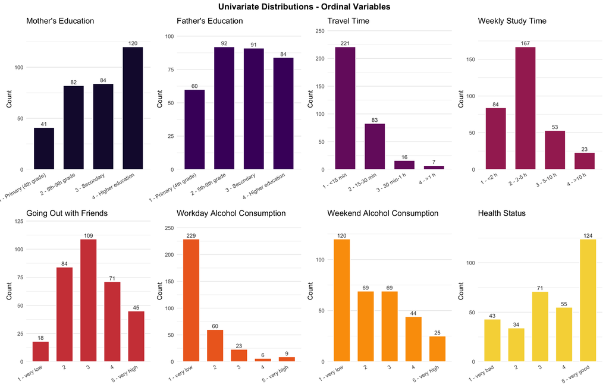

```r
pal_ord = viridis(8, option = VIR_PAL, begin = 0.1, end = 0.9)

# Labeled copy for plotting only — does not affect analytic datasets
d_mat_plot = d_mat_analysis |>
  mutate(
    goout = factor(goout, levels = 1:5,
                   labels = c("1 - very low", "2", "3", "4", "5 - very high")),
    Dalc = factor(Dalc, levels = 1:5,
                  labels = c("1 - very low", "2", "3", "4", "5 - very high")),
    Walc = factor(Walc, levels = 1:5,
                  labels = c("1 - very low", "2", "3", "4", "5 - very high")),
    health = factor(health, levels = 1:5,
                    labels = c("1 - very bad", "2", "3", "4", "5 - very good"))
    )

# Reusable function to make bar plots
make_bar = function(var, title, fill_col) {
  ggplot(d_mat_plot, aes(x = .data[[var]])) +
    geom_bar(fill = fill_col, colour = "white", width = 0.7) +
    geom_text(stat = "count", aes(label = after_stat(count)),
              vjust = -0.4, size = 3.2, colour = "grey20") +
    scale_y_continuous(expand = expansion(mult = c(0, 0.15))) +
    theme(axis.text.x  = element_text(angle = 30, hjust = 1),
          panel.grid.major.x = element_blank()) +
    labs(title = title, x = NULL, y = "Count")
}

p_medu = make_bar("Medu", "Mother's Education", pal_ord[1])
p_fedu = make_bar("Fedu", "Father's Education", pal_ord[2])
p_tt = make_bar("traveltime", "Travel Time", pal_ord[3])
p_st = make_bar("studytime", "Weekly Study Time", pal_ord[4])
p_go = make_bar("goout", "Going Out with Friends", pal_ord[5])
p_dalc = make_bar("Dalc", "Workday Alcohol Consumption", pal_ord[6])
p_walc = make_bar("Walc", "Weekend Alcohol Consumption", pal_ord[7])
p_hlth = make_bar("health", "Health Status", pal_ord[8])

(p_medu | p_fedu | p_tt | p_st) /
(p_go | p_dalc | p_walc | p_hlth) +
  plot_annotation(
    title = "Univariate Distributions - Ordinal Variables",
    theme = theme(plot.title = element_text(size = 14,
                                            face = "bold", hjust = 0.5)))
```

**Medu and Fedu**: In the case of mother’s education, the distribution is somewhat left-skewed, whereas the distribution for father’s education is closer to uniform. This observation was kept until multivariate analysis, where one variable may be prioritized.

**traveltime**: The distribution is right-skewed. The top two levels (16 and 7 observations) were merged into a single “>=30 min” category before model fitting, as small cell sizes in these strata would produce unstable coefficient estimates.

**studytime**: The distribution is reasonably spread, with the majority studying 2–5 hours per week. The upper level (>10 hours) is the smallest group with only 23 students - we thought of merging the two top categories, but in the end decided not to because we supposed that this is most likely one of the strongest predictors, and the strata size is small but not extremely.

**goout**: The distribution is close to symmetric and centered on level 3. Level 1 (“very low”) has only 18 students, which is notably sparse relative to the remaining levels, but since we code it as numeric, this should not play a significant role.

**Dalc and Walc**: These distributions differ notably; Dalc is heavily concentrated at “very low” (approximately 70.0%), with very sparse counts at levels 4 and 5. Walc is more spread across all levels, with counts for levels 4 and 5 still somewhat underrepresented but sufficient to retain as separate levels. Given their expected collinearity, the decision on retaining or excluding either variable was deferred until multivariate analysis.

**health**: The distribution is left-skewed. All five levels have reasonable counts.

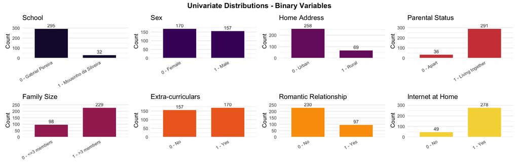

```r
pal_bin = viridis(8, option = VIR_PAL, begin = 0.1, end = 0.9)

p_sch = make_bar("school", "School", pal_bin[1])
p_sex = make_bar("sex", "Sex", pal_bin[2])
p_adr = make_bar("address", "Home Address", pal_bin[3])
p_fsz = make_bar("famsize", "Family Size", pal_bin[4])
p_pst = make_bar("Pstatus", "Parental Status", pal_bin[5])
p_act = make_bar("activities", "Extra-curriculars", pal_bin[6])
p_rom = make_bar("romantic", "Romantic Relationship", pal_bin[7])
p_net = make_bar("internet", "Internet at Home", pal_bin[8])

(p_sch | p_sex | p_adr | p_pst) /
(p_fsz | p_act | p_rom | p_net) +
  plot_annotation(
    title = "Univariate Distributions - Binary Variables",
    theme = theme(plot.title = element_text(size = 14,
                                            face = "bold", hjust = 0.5)))
```

For **school**, the sample is heavily dominated by Gabriel Pereira, with only 32 students from Mousinho da Silveira. This imbalance is worth keeping in mind as the school coefficient will be estimated from a very small contrast group.

For **sex**, the split is nearly equal.

For **address**, the majority of students live in urban area, with rural students representing about a fifth of the sample - both groups are sufficiently represented.

For **famsize and Pstatus**, both variables show imbalanced distributions in the same direction: most students come from larger families and from households where parents live together. The “Apart” category for Pstatus is particularly sparse, which may produce an unstable estimate - we kept this in mind.

For **activities and romantic**, activities is nearly balanced. Romantic relationships are less common but still well-represented, with a little bit less than third of students reporting being in a relationship.

For **internet**, the large majority of students have internet access at home, leaving only 49 without. This imbalance is not extreme enough to require action, but we kept it in mind.

### IDA Screening: Multivariate Descriptions

We performed stratification on two general variables, namely, by **sex** and by **school**. Stratification by all remaining variables was omitted to avoid inflating the report with uninformative visuals - the correlation structure between predictors will be addressed more systematically in the subsequent correlation and redundancy analysis.

#### Stratification by Sex

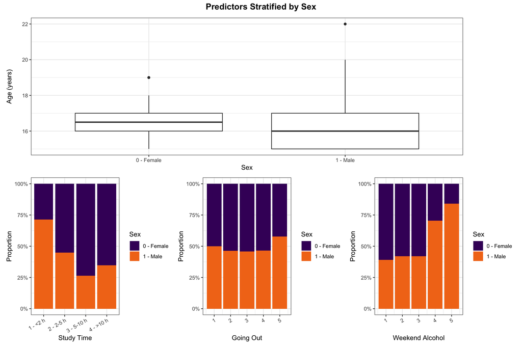

```r
p1 = ggplot(d_mat_analysis, aes(x = sex, y = age)) +
  geom_boxplot() + theme_bw() +
  labs(x = "Sex", y = "Age (years)")

p2 = ggplot(d_mat_analysis, aes(x = studytime, fill = sex)) +
  geom_bar(position = "fill") +
  scale_fill_viridis_d(option = VIR_PAL, begin = 0.2, end = 0.7, name = "Sex") +
  scale_y_continuous(labels = scales::label_percent()) +
  theme_bw() +
  theme(axis.text.x = element_text(angle = 30, hjust = 1)) +
  labs(x = "Study Time", y = "Proportion")

p3 = ggplot(d_mat_analysis, aes(x = goout, fill = sex)) +
  geom_bar(position = "fill") +
  scale_fill_viridis_d(option = VIR_PAL, begin = 0.2, end = 0.7, name = "Sex") +
  scale_y_continuous(labels = scales::label_percent()) +
  theme_bw() +
  theme(axis.text.x = element_text(angle = 30, hjust = 1)) +
  labs(x = "Going Out", y = "Proportion")

p4 = ggplot(d_mat_analysis, aes(x = Walc, fill = sex)) +
  geom_bar(position = "fill") +
  scale_fill_viridis_d(option = VIR_PAL, begin = 0.2, end = 0.7, name = "Sex") +
  scale_y_continuous(labels = scales::label_percent()) +
  theme_bw() +
  theme(axis.text.x = element_text(angle = 30, hjust = 1)) +
  labs(x = "Weekend Alcohol", y = "Proportion")

(p1) / (p2 | p3 | p4) +
  plot_annotation(
    title = "Predictors Stratified by Sex",
    theme = theme(plot.title = element_text(size = 14,
                                            face = "bold", hjust = 0.5)))
```

Notable observations are: that female student spent more time studying, and consume smaller amount of alcohol on weekends compared to male students in this sample; especially when it comes to higher amounts of consumption. In terms of age female students are a little bit older and their age is less spread out compared to male students.

#### Stratification by School

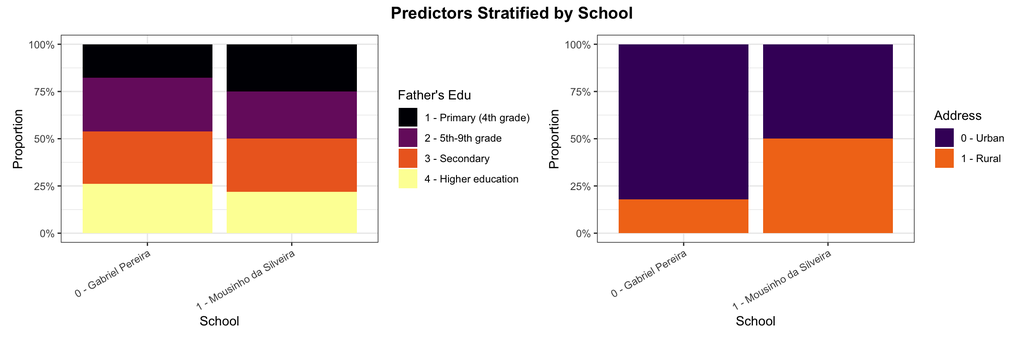

```r
rot_x = theme(axis.text.x = element_text(angle = 30, hjust = 1))

p1 = ggplot(d_mat_analysis, aes(x = school, fill = Fedu)) +
  geom_bar(position = "fill") +
  scale_fill_viridis_d(option = VIR_PAL, name = "Father's Edu") +
  scale_y_continuous(labels = scales::label_percent()) +
  theme_bw() +
  rot_x +
  labs(x = "School", y = "Proportion")

p2 = ggplot(d_mat_analysis, aes(x = school, fill = address)) +
  geom_bar(position = "fill") +
  scale_fill_viridis_d(option = VIR_PAL, begin = 0.2, end = 0.7,
                       name = "Address") +
  scale_y_continuous(labels = scales::label_percent()) +
  theme_bw() +
  rot_x +
  labs(x = "School", y = "Proportion")

(p1 | p2) +
  plot_annotation(
    title = "Predictors Stratified by School",
    theme = theme(plot.title = element_text(size = 14,
                                            face = "bold", hjust = 0.5)))
```

Notable observations are: that for students from Mousinho da Silveira their fathers have somewhat lower education levels, and a significantly larger proportion of them live in rural areas compared to students from Gabriel Pereira in this sample. However, both schools remain largely comparable, with Mousinho da Silveira simply reflecting slightly more pronounced environmental and socioeconomic constraints.

#### Correlation Between All Predictors

We now summarize all of the correlations.

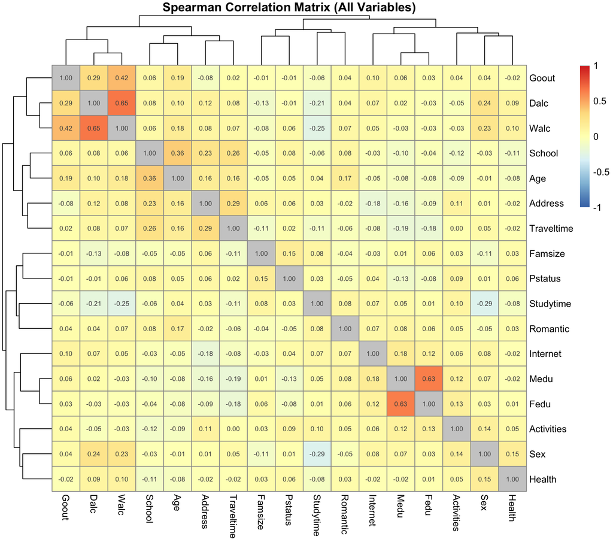

```r
# Make a numeric-only dataframe where factors are converted to ranks
cor_all_df = d_mat_analysis |>
  mutate(
    School = as.numeric(school) - 1,
    Sex = as.numeric(sex) - 1,
    Age = age,
    Address = as.numeric(address) - 1,
    Famsize = as.numeric(famsize) - 1,
    Pstatus = as.numeric(Pstatus) - 1,
    Medu = as.numeric(Medu),
    Fedu = as.numeric(Fedu),
    Traveltime = as.numeric(traveltime),
    Internet = as.numeric(internet) - 1,
    Studytime = as.numeric(studytime),
    Activities = as.numeric(activities) - 1,
    Romantic = as.numeric(romantic) - 1,
    Goout = as.numeric(goout),
    Dalc = as.numeric(Dalc),
    Walc = as.numeric(Walc),
    Health = as.numeric(health)
  ) |>
  select(School, Sex, Age, Address, Famsize, Pstatus, Medu, Fedu,
         Traveltime, Internet, Studytime, Activities, Romantic,
         Goout, Dalc, Walc, Health)

# Use Spearman correlation
cor_matrix = cor(cor_all_df, use = "pairwise.complete.obs",
                 method = "spearman")

Breaks = seq(-1, 1, by=.01)
my_palette = c(colorRampPalette(rev(RColorBrewer::brewer.pal(n = 7,
                                      name ="RdYlBu")))
                (length(Breaks)-2), "grey80", "grey80")

pheatmap(cor_matrix, cluster_cols= TRUE, cluster_rows = TRUE,
         display_numbers = TRUE, fontsize_number = 7,
         main= "Spearman Correlation Matrix (All Variables)",
         breaks = Breaks, color = my_palette)
```

We observe some expected clusters. The strongest positive correlations are between Mother’s Education (`Medu`) and Father’s Education (`Fedu`), as well as between Workday Alcohol Consumption (`Dalc`) and Weekend Alcohol Consumption (`Walc`) - what we hypothesized in the beginning. There is also a notable positive association between `Walc` and `Goout` (similarly for `Dalc` and `Goout` but weaker) - which is expectable given that some of going out activities include alcohol consumption. Additionaly, there is a negative association between `studytime` and `sex` - the observation we made when performing stratification by sex.

To make a final decision of keeping or not keeping all of the variables, we wanted to perform Redundancy Analysis.

#### Redundancy Analysis

Note that we set nk = 0 to suppress spline transformations, as most predictors have only 4 ordinal levels - too few to support non-linear fits. This reduces the redundancy analysis to a linear R² check rather than a full non-linear redundancy assessment.

```r
Hmisc::redun(~ age + school + sex + address + famsize + Pstatus +
               Medu + Fedu + traveltime + internet + health +
               goout + activities + Dalc + Walc + studytime + romantic,
             data = d_combined,
             nk = 0)
```

```
Redundancy Analysis

~age + school + sex + address + famsize + Pstatus + Medu + Fedu +
    traveltime + internet + health + goout + activities + Dalc +
    Walc + studytime + romantic

n: 327  p: 17   nk: 0

Number of NAs:   0

Transformation of target variables forced to be linear

R-squared cutoff: 0.9   Type: ordinary

R^2 with which each variable can be predicted from all other variables:

       age     school        sex    address    famsize    Pstatus       Medu
     0.225      0.244      0.207      0.233      0.096      0.122      0.455
      Fedu traveltime   internet     health      goout activities       Dalc
     0.432      0.225      0.106      0.095      0.262      0.126      0.484
      Walc  studytime   romantic
     0.554      0.204      0.118

No redundant variables
```

The redundancy analysis showed that no variable exceeds the R^2 = 0.9 redundancy threshold, meaning no predictor can be linearly reconstructed from the remaining variables with sufficient precision to warrant automatic exclusion. The highest R^2 values belong to `Walc` (0.554) and `Dalc` (0.484), reflecting their shared alcohol-consumption construct – consistent with the strong correlation observed in the heatmap. `Medu` and `Fedu` follow at 0.455 and 0.432 respectively, again expected given their correlation, but well below the redundancy cutoff. All remaining variables have R² below 0.33, indicating they each contribute largely independent information. On these facts alone, no variable would be excluded - however, the decisions were revisited in the IDA conclusions.

### IDA Conclusions

Based on the screening, three sets of decisions are carried into model fitting.

**Variable exclusion.** `Dalc` is dropped from the analytic models. This decision is not motivated by multicollinearity (which as we have seen is present, but not extreme), rather, the justification is distributional: most of students score at the lowest level, and after collapsing the sparse upper categories the variable would effectively reduce to a near-binary indicator. `Walc`, which is better spread across all five levels and captures the same underlying alcohol consumption construct, is thus kept as the sole alcohol predictor.

**Level recoding**. For `traveltime`, the top two levels (“30 min–1 h” and “>1 h”) are merged into a single “>=30 min” category, as the original cell sizes (16 and 7 observations respectively) were too small to produce meaningful coefficient estimates.

**Underrepresented categories.** Three binary variables show notable imbalance: `school` (only 32 students from Mousinho da Silveira), `Pstatus` (sparse “Apart” category), and `internet` (only 49 students without home access). These variables are kept in the models, as their imbalance is not severe enough to motivate exclusion and each carries plausible theoretical relevance. However, their coefficient estimates should be interpreted with caution - the contrast groups are small, confidence intervals will be wide, and any effects may be unstable.

Additionally, age is mean-centered in this step - while strictly a modeling preparation rather than an IDA decision, it is applied here since all exclusions are finalized and the mean is therefore computed on the correct analytic sample.

```r
# Drop Dalc from behavioural variable list
behavioural_vars = c("goout", "activities", "Walc", "studytime", "romantic")

# Collapse traveltime: merge levels 3 and 4 into "3 - >=30 min"
d_combined$traveltime = fct_collapse(
  d_combined$traveltime,
  "3 - >=30 min" = c("3 - 30 min-1 h", "4 - >1 h"))
d_combined$traveltime = droplevels(d_combined$traveltime)

# Reapply successive difference contrasts after level change
contrasts(d_combined$traveltime) = MASS::contr.sdif(
  length(levels(d_combined$traveltime)))

# Center the age
d_combined$age = d_combined$age - mean(d_combined$age)

# Regenerate analytic datasets with updated variable list and recodings
d_mat_analysis = prepare_subject_data(d_combined, ".mat")
d_por_analysis = prepare_subject_data(d_combined, ".por")
```

### Final Summary Before Analysis

```r
var_summary = tribble(
  ~Group, ~Variable, ~Type, ~Levels,
  "General",     "school",     "Binary",  paste(levels(d_combined$school), collapse = " / "),
  "General",     "sex",        "Binary",  paste(levels(d_combined$sex), collapse = " / "),
  "General",     "age",        "Numeric", "15-22 (mean-centered)",
  "Behavioural", "goout",      "Numeric", "1 (low) – 5 (very high)",
  "Behavioural", "activities", "Binary",  paste(levels(d_combined$activities), collapse = " / "),
  "Behavioural", "Walc",       "Numeric", "1 (very low) – 5 (very high)",
  "Behavioural", "studytime",  "Ordinal", paste(levels(d_combined$studytime), collapse = " / "),
  "Behavioural", "romantic",   "Binary",  paste(levels(d_combined$romantic), collapse = " / "),
  "Structural",  "address",    "Binary",  paste(levels(d_combined$address), collapse = " / "),
  "Structural",  "famsize",    "Binary",  paste(levels(d_combined$famsize), collapse = " / "),
  "Structural",  "Pstatus",    "Binary",  paste(levels(d_combined$Pstatus), collapse = " / "),
  "Structural",  "Medu",       "Ordinal", paste(levels(d_combined$Medu), collapse = " / "),
  "Structural",  "Fedu",       "Ordinal", paste(levels(d_combined$Fedu), collapse = " / "),
  "Structural",  "traveltime", "Ordinal", paste(levels(d_combined$traveltime), collapse = " / "),
  "Structural",  "internet",   "Binary",  paste(levels(d_combined$internet), collapse = " / "),
  "Structural",  "health",     "Numeric", "1 (very bad) – 5 (very good)",
  "Outcome",     "G3",         "Numeric", "1-20"
)

var_summary |>
  gt(groupname_col = "Group") |>
  tab_header(
    title = "Final Analytic Variable Set",
    subtitle = paste0("n = ", nrow(d_combined), " observations")) |>
  cols_label(Variable = "Variable", Type = "Type", Levels = "Levels / Range") |>
  tab_style(style = cell_text(weight = "bold"),
            locations = cells_row_groups()) |>
  tab_style(style = cell_text(style = "italic"),
            locations = cells_body(columns = Variable))
```

Final Analytic Variable Set

n = 327 observations

| Variable | Type | Levels / Range |
| --- | --- | --- |
| General |  |  |
| school | Binary | 0 - Gabriel Pereira / 1 - Mousinho da Silveira |
| sex | Binary | 0 - Female / 1 - Male |
| age | Numeric | 15-22 (mean-centered) |
| Behavioural |  |  |
| goout | Numeric | 1 (low) – 5 (very high) |
| activities | Binary | 0 - No / 1 - Yes |
| Walc | Numeric | 1 (very low) – 5 (very high) |
| studytime | Ordinal | 1 - <2 h / 2 - 2-5 h / 3 - 5-10 h / 4 - >10 h |
| romantic | Binary | 0 - No / 1 - Yes |
| Structural |  |  |
| address | Binary | 0 - Urban / 1 - Rural |
| famsize | Binary | 0 - <=3 members / 1 - >3 members |
| Pstatus | Binary | 0 - Apart / 1 - Living together |
| Medu | Ordinal | 1 - Primary (4th grade) / 2 - 5th-9th grade / 3 - Secondary / 4 - Higher education |
| Fedu | Ordinal | 1 - Primary (4th grade) / 2 - 5th-9th grade / 3 - Secondary / 4 - Higher education |
| traveltime | Ordinal | 1 - <15 min / 2 - 15-30 min / 3 - >=30 min |
| internet | Binary | 0 - No / 1 - Yes |
| health | Numeric | 1 (very bad) – 5 (very good) |
| Outcome |  |  |
| G3 | Numeric | 1-20 |

## Model Analysis

### Fit the Models

```r
formula_structural = G3 ~ school + sex + age +
  address + famsize + Pstatus + Medu + Fedu +
  traveltime + internet + health

formula_full = update(formula_structural,
  . ~ . + goout + activities + Walc + studytime + romantic)

mod_mat_struct = lm(formula_structural, data = d_mat_analysis)
mod_mat_full = lm(formula_full, data = d_mat_analysis)
mod_por_struct = lm(formula_structural, data = d_por_analysis)
mod_por_full = lm(formula_full, data = d_por_analysis)
```

```r
term_labels = c(
  `(Intercept)`  = "Intercept",
  `school1 - Mousinho da Silveira` = "School: Mousinho da Silveira (ref: Gabriel Pereira)",
  `sex1 - Male` = "Sex: Male (ref: Female)",
  `age` = "Age (mean-centered)",
  `address1 - Rural` = "Address: Rural (ref: Urban)",
  `famsize1 - >3 members` = "Family Size: >3 (ref: <=3)",
  `Pstatus1 - Living together` = "Parental Status: Together (ref: Apart)",
  `Medu2-1` = "Mother's Edu: 5th-9th vs Primary",
  `Medu3-2` = "Mother's Edu: Secondary vs 5th-9th",
  `Medu4-3` = "Mother's Edu: Higher vs Secondary",
  `Fedu2-1` = "Father's Edu: 5th-9th vs Primary",
  `Fedu3-2` = "Father's Edu: Secondary vs 5th-9th",
  `Fedu4-3` = "Father's Edu: Higher vs Secondary",
  `traveltime2-1` = "Travel: 15-30 min vs <15 min",
  `traveltime3-2` = "Travel: >=30 min vs 15-30 min",
  `internet1 - Yes`= "Internet: Yes (ref: No)",
  `health` = "Health (numeric, 1–5)",
  `goout` = "Going Out (numeric, 1–5)",
  `activities1 - Yes` = "Activities: Yes (ref: No)",
  `Walc` = "Weekend Alcohol (numeric, 1–5)",
  `studytime2-1` = "Study Time: 2-5 h vs <2 h",
  `studytime3-2` = "Study Time: 5-10 h vs 2-5 h",
  `studytime4-3` = "Study Time: >10 h vs 5-10 h",
  `romantic1 - Yes` = "Romantic: Yes (ref: No)"
)

make_coef_table = function(model, title_str) {
  tidy(model, conf.int = TRUE) |>
    mutate(term = recode(term, !!!term_labels)) |>
    select(Term = term, Estimate = estimate,
           `95% CI lower` = conf.low,
           `95% CI upper` = conf.high,
           `p-value` = p.value) |>
    gt() |>
    tab_header(title = title_str,
               subtitle = "Estimates with 95% Confidence Intervals") |>
    fmt_number(columns = c(Estimate, `95% CI lower`, `95% CI upper`),
               decimals = 3) |>
    fmt_scientific(columns = `p-value`, decimals = 2) |>
    tab_style(style = cell_text(weight = "bold"),
              locations = cells_body(rows = `p-value` < 0.05))
}
```

### Mathematics

In this subsection we will focus on interpretation of the effects for Mathematics.

#### Coefficients of Structural Model

```r
make_coef_table(mod_mat_struct, "Mathematics - Structural Model")
```

Mathematics - Structural Model

Estimates with 95% Confidence Intervals

| Term | Estimate | 95% CI lower | 95% CI upper | p-value |
| --- | --- | --- | --- | --- |
| Intercept | 11.557 | 9.853 | 13.260 | 2.03 × 10<sup>−32</sup> |
| School: Mousinho da Silveira (ref: Gabriel Pereira) | 0.426 | −0.881 | 1.734 | 5.22 × 10<sup>−1</sup> |
| Sex: Male (ref: Female) | 0.937 | 0.229 | 1.645 | 9.65 × 10<sup>−3</sup> |
| Age (mean-centered) | −0.301 | −0.625 | 0.023 | 6.88 × 10<sup>−2</sup> |
| Address: Rural (ref: Urban) | −0.470 | −1.400 | 0.461 | 3.22 × 10<sup>−1</sup> |
| Family Size: >3 (ref: <=3) | −0.199 | −0.978 | 0.579 | 6.15 × 10<sup>−1</sup> |
| Parental Status: Together (ref: Apart) | 0.270 | −0.884 | 1.424 | 6.46 × 10<sup>−1</sup> |
| Mother's Edu: 5th-9th vs Primary | 1.121 | −0.177 | 2.418 | 9.02 × 10<sup>−2</sup> |
| Mother's Edu: Secondary vs 5th-9th | 0.208 | −0.827 | 1.243 | 6.93 × 10<sup>−1</sup> |
| Mother's Edu: Higher vs Secondary | 0.617 | −0.359 | 1.592 | 2.14 × 10<sup>−1</sup> |
| Father's Edu: 5th-9th vs Primary | 0.332 | −0.784 | 1.449 | 5.58 × 10<sup>−1</sup> |
| Father's Edu: Secondary vs 5th-9th | −0.715 | −1.704 | 0.275 | 1.56 × 10<sup>−1</sup> |
| Father's Edu: Higher vs Secondary | 0.927 | −0.081 | 1.935 | 7.14 × 10<sup>−2</sup> |
| Travel: 15-30 min vs <15 min | −0.353 | −1.197 | 0.491 | 4.11 × 10<sup>−1</sup> |
| Travel: >=30 min vs 15-30 min | 0.018 | −1.503 | 1.538 | 9.82 × 10<sup>−1</sup> |
| Internet: Yes (ref: No) | 0.189 | −0.811 | 1.189 | 7.10 × 10<sup>−1</sup> |
| Health (numeric, 1–5) | −0.280 | −0.532 | −0.028 | 2.96 × 10<sup>−2</sup> |

#### Coefficients of Full Model

```r
make_coef_table(mod_mat_full, "Mathematics - Full Model")
```

Mathematics - Full Model

Estimates with 95% Confidence Intervals

| Term | Estimate | 95% CI lower | 95% CI upper | p-value |
| --- | --- | --- | --- | --- |
| Intercept | 14.241 | 12.304 | 16.178 | 1.97 × 10<sup>−36</sup> |
| School: Mousinho da Silveira (ref: Gabriel Pereira) | 0.527 | −0.747 | 1.802 | 4.16 × 10<sup>−1</sup> |
| Sex: Male (ref: Female) | 1.273 | 0.537 | 2.009 | 7.53 × 10<sup>−4</sup> |
| Age (mean-centered) | −0.168 | −0.492 | 0.156 | 3.08 × 10<sup>−1</sup> |
| Address: Rural (ref: Urban) | −0.794 | −1.717 | 0.128 | 9.13 × 10<sup>−2</sup> |
| Family Size: >3 (ref: <=3) | −0.382 | −1.139 | 0.375 | 3.21 × 10<sup>−1</sup> |
| Parental Status: Together (ref: Apart) | 0.099 | −1.023 | 1.221 | 8.62 × 10<sup>−1</sup> |
| Mother's Edu: 5th-9th vs Primary | 0.820 | −0.438 | 2.078 | 2.01 × 10<sup>−1</sup> |
| Mother's Edu: Secondary vs 5th-9th | 0.282 | −0.722 | 1.286 | 5.81 × 10<sup>−1</sup> |
| Mother's Edu: Higher vs Secondary | 0.572 | −0.377 | 1.520 | 2.36 × 10<sup>−1</sup> |
| Father's Edu: 5th-9th vs Primary | 0.384 | −0.692 | 1.460 | 4.83 × 10<sup>−1</sup> |
| Father's Edu: Secondary vs 5th-9th | −0.652 | −1.614 | 0.309 | 1.83 × 10<sup>−1</sup> |
| Father's Edu: Higher vs Secondary | 0.965 | −0.011 | 1.941 | 5.27 × 10<sup>−2</sup> |
| Travel: 15-30 min vs <15 min | −0.406 | −1.222 | 0.410 | 3.28 × 10<sup>−1</sup> |
| Travel: >=30 min vs 15-30 min | 0.474 | −1.011 | 1.959 | 5.30 × 10<sup>−1</sup> |
| Internet: Yes (ref: No) | 0.167 | −0.807 | 1.142 | 7.35 × 10<sup>−1</sup> |
| Health (numeric, 1–5) | −0.279 | −0.524 | −0.034 | 2.58 × 10<sup>−2</sup> |
| Going Out (numeric, 1–5) | −0.377 | −0.722 | −0.031 | 3.28 × 10<sup>−2</sup> |
| Activities: Yes (ref: No) | 0.115 | −0.590 | 0.820 | 7.48 × 10<sup>−1</sup> |
| Weekend Alcohol (numeric, 1–5) | −0.303 | −0.616 | 0.009 | 5.73 × 10<sup>−2</sup> |
| Study Time: 2-5 h vs <2 h | −0.524 | −1.379 | 0.332 | 2.29 × 10<sup>−1</sup> |
| Study Time: 5-10 h vs 2-5 h | 1.522 | 0.525 | 2.520 | 2.90 × 10<sup>−3</sup> |
| Study Time: >10 h vs 5-10 h | 0.267 | −1.268 | 1.801 | 7.33 × 10<sup>−1</sup> |
| Romantic: Yes (ref: No) | −0.280 | −1.042 | 0.482 | 4.71 × 10<sup>−1</sup> |

#### Interpretation of Coefficients

##### Structural Model

Only two structural predictors reach significance. **Sex** is the clearest signal: male students score 0.94 points higher on average (95% CI: 0.23–1.65). **Health** is the other, and its direction is counterintuitive - each unit increase on the 1–5 scale (bigger value the better is reported health) is associated with a 0.28 point *decrease* in grade (p = 0.030). All remaining structural predictors - parental education, travel time, internet, address, family size, school — are non-significant, suggesting that environmental background explains very little of the variation in mathematics performance on its own.

##### Full Model

**Sex** remains significant and grows slightly: male students score 1.27 points higher (95% CI: 0.54–2.01). The fact that the gap widens after conditioning on study time - given that female students were observed to study more in the IDA - suggests that behavioral differences partially offset rather than explain the underlying grade gap. **Health** retains the same negative estimate (−0.28, p = 0.026); we suspect confounding with social lifestyle, but the consistency across both models confirms it is not a modeling artifact.

Among behavioral predictors, **study time** shows the clearest effect, though the pattern is non-monotone across contrasts. The jump from 2–5 hours to 5–10 hours per week is the strongest single effect in the model (+1.52 points, 95% CI: 0.53–2.52), while the contrasts involving the lowest and highest study groups are small and non-significant. This points to a threshold effect: moving from moderate to substantial weekly study time matters, but studying beyond that does not yield further gains.

**Going out** is the one other behavioral predictor that is significant: each additional unit on the 1–5 scale is associated with a 0.38 point decrease in grade (95% CI: −0.72 to −0.03). **Weekend alcohol** is borderline (−0.30, p = 0.057) and we would not claim it as a finding, though its direction is consistent with the broader pattern of social-behavioral factors pulling grades down. **Romantic relationship** and **activities** are both non-significant with near-zero estimates.

Note that the intercept is not interpreted. With successive difference contrasts applied to the ordered factors (parental education, travel time, study time), the intercept represents the mean across factor levels rather than a value at any natural reference category. It does not correspond to an interpretable student profile.

Overall, structural background has little detectable independent effect on mathematics grades, with the exception of the persistent sex gap. The behavioral predictors - primarily study time intensity and time spent going out - carry the meaningful explanatory signal in this subject.

### Portuguese

In this subsection we focus on Portuguese, but also conecting it to results of Mathematics.

#### Coefficients of Structural Model

```r
make_coef_table(mod_por_struct, "Portuguese - Structural Model")
```

Portuguese - Structural Model

Estimates with 95% Confidence Intervals

| Term | Estimate | 95% CI lower | 95% CI upper | p-value |
| --- | --- | --- | --- | --- |
| Intercept | 14.150 | 12.834 | 15.466 | 4.27 × 10<sup>−62</sup> |
| School: Mousinho da Silveira (ref: Gabriel Pereira) | −0.283 | −1.293 | 0.727 | 5.82 × 10<sup>−1</sup> |
| Sex: Male (ref: Female) | −0.970 | −1.517 | −0.423 | 5.55 × 10<sup>−4</sup> |
| Age (mean-centered) | 0.234 | −0.016 | 0.484 | 6.67 × 10<sup>−2</sup> |
| Address: Rural (ref: Urban) | −0.609 | −1.328 | 0.109 | 9.63 × 10<sup>−2</sup> |
| Family Size: >3 (ref: <=3) | −0.047 | −0.649 | 0.555 | 8.78 × 10<sup>−1</sup> |
| Parental Status: Together (ref: Apart) | −0.147 | −1.039 | 0.744 | 7.45 × 10<sup>−1</sup> |
| Mother's Edu: 5th-9th vs Primary | 0.226 | −0.776 | 1.229 | 6.57 × 10<sup>−1</sup> |
| Mother's Edu: Secondary vs 5th-9th | 0.248 | −0.551 | 1.048 | 5.42 × 10<sup>−1</sup> |
| Mother's Edu: Higher vs Secondary | 0.884 | 0.131 | 1.637 | 2.16 × 10<sup>−2</sup> |
| Father's Edu: 5th-9th vs Primary | 0.250 | −0.612 | 1.113 | 5.68 × 10<sup>−1</sup> |
| Father's Edu: Secondary vs 5th-9th | −0.538 | −1.302 | 0.226 | 1.67 × 10<sup>−1</sup> |
| Father's Edu: Higher vs Secondary | 0.636 | −0.143 | 1.415 | 1.09 × 10<sup>−1</sup> |
| Travel: 15-30 min vs <15 min | −0.057 | −0.710 | 0.595 | 8.62 × 10<sup>−1</sup> |
| Travel: >=30 min vs 15-30 min | −0.271 | −1.446 | 0.903 | 6.50 × 10<sup>−1</sup> |
| Internet: Yes (ref: No) | 0.032 | −0.740 | 0.805 | 9.35 × 10<sup>−1</sup> |
| Health (numeric, 1–5) | −0.226 | −0.421 | −0.032 | 2.27 × 10<sup>−2</sup> |

#### Coefficients of Full Model

```r
make_coef_table(mod_por_full, "Portuguese - Full Model")
```

Portuguese - Full Model

Estimates with 95% Confidence Intervals

| Term | Estimate | 95% CI lower | 95% CI upper | p-value |
| --- | --- | --- | --- | --- |
| Intercept | 16.136 | 14.659 | 17.613 | 6.39 × 10<sup>−63</sup> |
| School: Mousinho da Silveira (ref: Gabriel Pereira) | −0.085 | −1.056 | 0.887 | 8.64 × 10<sup>−1</sup> |
| Sex: Male (ref: Female) | −0.612 | −1.173 | −0.051 | 3.26 × 10<sup>−2</sup> |
| Age (mean-centered) | 0.351 | 0.104 | 0.598 | 5.53 × 10<sup>−3</sup> |
| Address: Rural (ref: Urban) | −0.942 | −1.646 | −0.239 | 8.82 × 10<sup>−3</sup> |
| Family Size: >3 (ref: <=3) | −0.126 | −0.703 | 0.452 | 6.69 × 10<sup>−1</sup> |
| Parental Status: Together (ref: Apart) | −0.284 | −1.139 | 0.572 | 5.15 × 10<sup>−1</sup> |
| Mother's Edu: 5th-9th vs Primary | 0.062 | −0.897 | 1.021 | 8.99 × 10<sup>−1</sup> |
| Mother's Edu: Secondary vs 5th-9th | 0.327 | −0.439 | 1.092 | 4.02 × 10<sup>−1</sup> |
| Mother's Edu: Higher vs Secondary | 0.831 | 0.108 | 1.554 | 2.45 × 10<sup>−2</sup> |
| Father's Edu: 5th-9th vs Primary | 0.236 | −0.584 | 1.057 | 5.71 × 10<sup>−1</sup> |
| Father's Edu: Secondary vs 5th-9th | −0.625 | −1.358 | 0.107 | 9.41 × 10<sup>−2</sup> |
| Father's Edu: Higher vs Secondary | 0.755 | 0.011 | 1.499 | 4.68 × 10<sup>−2</sup> |
| Travel: 15-30 min vs <15 min | −0.063 | −0.685 | 0.559 | 8.43 × 10<sup>−1</sup> |
| Travel: >=30 min vs 15-30 min | 0.180 | −0.952 | 1.312 | 7.55 × 10<sup>−1</sup> |
| Internet: Yes (ref: No) | 0.025 | −0.718 | 0.768 | 9.47 × 10<sup>−1</sup> |
| Health (numeric, 1–5) | −0.219 | −0.406 | −0.032 | 2.17 × 10<sup>−2</sup> |
| Going Out (numeric, 1–5) | −0.427 | −0.691 | −0.164 | 1.57 × 10<sup>−3</sup> |
| Activities: Yes (ref: No) | 0.443 | −0.094 | 0.981 | 1.06 × 10<sup>−1</sup> |
| Weekend Alcohol (numeric, 1–5) | −0.174 | −0.412 | 0.065 | 1.52 × 10<sup>−1</sup> |
| Study Time: 2-5 h vs <2 h | 0.590 | −0.063 | 1.242 | 7.63 × 10<sup>−2</sup> |
| Study Time: 5-10 h vs 2-5 h | 0.844 | 0.083 | 1.604 | 2.98 × 10<sup>−2</sup> |
| Study Time: >10 h vs 5-10 h | −0.029 | −1.198 | 1.141 | 9.62 × 10<sup>−1</sup> |
| Romantic: Yes (ref: No) | −0.260 | −0.841 | 0.321 | 3.80 × 10<sup>−1</sup> |

#### Interpretation of Coefficients

The intercept is not interpreted for the same reasons stated for the Mathematics models.

##### Structural Model

As in Mathematics, **health** is significant and negative (−0.23, p = 0.023), consistent across both subjects and both models. **Sex** is again the clearest structural signal, but the direction reverses: female students score 0.97 points *higher* in Portuguese (95% CI: 0.42–1.52), compared to male students scoring higher in Mathematics.

Parental education is non-significant, with one exception: the contrast between higher education and secondary for mother’s education reaches significance (+0.88, p = 0.022).Unlike for Mathemtacis this suggests that the benefit of parental education for Portuguese grades is significant but just compared to parents having higher degree and having secondary school degree. All remaining structural predictors — school, family size, parental status, travel time, internet, address — are non-significant.

##### Full Model

**Sex** remains significant after adding behavioral predictors, though the estimate attenuates to −0.61 (p = 0.033), suggesting behavioral differences between sexes explain part of the gap. **Age** becomes significant in the full model (+0.35 per year, 95% CI: 0.10–0.60), which was not the case in the structural model - this is likely a suppression effect, where behavioral variables that correlate with age were masking its association with the grade. **Address** also crosses the significance threshold in the full model: rural students score 0.94 points lower on average (95% CI: −1.65 to −0.24), a pattern absent in Mathematics. **Health** keeps its negative estimate (−0.22, p = 0.022), again consistent with Mathematics. The mother’s education contrast (Higher vs Secondary) remains significant at +0.83 (p = 0.025), and father’s education at the same contrast now also reaches significance (+0.76, p = 0.047) - a stronger parental education signal than in Mathematics overall.

Among behavioral predictors, **going out** is significant and negative (−0.43 per unit, 95% CI: −0.69 to −0.16), consistent with Mathematics in both direction and magnitude. **Study time** again shows a non-monotone pattern, but smaller compared to Mathematics: the 5–10 h vs 2–5 h contrast is significant (+0.84, p = 0.030), while the lowest and highest contrasts are not — the same threshold structure as in Mathematics, but with a smaller effect at the critical step. **Weekend alcohol**, **romantic relationship**, and **activities** are all non-significant, mirroring the Mathematics results.

The overall picture is largely consistent with Mathematics: structural background is weak, the sex gap persists but flips direction, and the behavioral signal is again concentrated in study time intensity and going out. The notable differences are that Portuguese grades show a stronger parental education effect at the upper end, a rural address penalty absent in Mathematics, and an age effect that only emerges once behavioral variables are controlled for.

### Model Comparison

In this subsection we compare the predictive power of the models.

```r
rmse = function(model) sqrt(mean(resid(model)^2))
mae  = function(model) mean(abs(resid(model)))

comparison = tibble(
  Subject = c("Mathematics", "Mathematics", "Portuguese", "Portuguese"),
  Model = c("Structural", "Full", "Structural", "Full"),
  AIC = c(AIC(mod_mat_struct), AIC(mod_mat_full),
          AIC(mod_por_struct), AIC(mod_por_full)),
  RMSE = c(rmse(mod_mat_struct), rmse(mod_mat_full),
           rmse(mod_por_struct), rmse(mod_por_full)),
  MAE = c(mae(mod_mat_struct),  mae(mod_mat_full),
          mae(mod_por_struct),  mae(mod_por_full)),
  R2 = c(summary(mod_mat_struct)$r.squared,
         summary(mod_mat_full)$r.squared,
         summary(mod_por_struct)$r.squared,
         summary(mod_por_full)$r.squared),
  Adj_R2 = c(summary(mod_mat_struct)$adj.r.squared,
             summary(mod_mat_full)$adj.r.squared,
             summary(mod_por_struct)$adj.r.squared,
             summary(mod_por_full)$adj.r.squared))

comparison |>
  gt(groupname_col = "Subject") |>
  tab_header(title = "Model Comparison",
             subtitle = "Structural vs Full model across both subjects") |>
  fmt_number(columns = c(AIC, RMSE, MAE), decimals = 2) |>
  fmt_number(columns = c(R2, Adj_R2), decimals = 3) |>
  cols_label(Adj_R2 = "Adj. R²", R2 = "R²") |>
  tab_style(style = cell_text(weight = "bold"),
            locations = cells_row_groups())
```

Model Comparison

Structural vs Full model across both subjects

| Model | AIC | RMSE | MAE | R² | Adj. R² |
| --- | --- | --- | --- | --- | --- |
| Mathematics |  |  |  |  |  |
| Structural | 1,698.40 | 3.07 | 2.48 | 0.114 | 0.068 |
| Full | 1,678.27 | 2.92 | 2.38 | 0.202 | 0.141 |
| Portuguese |  |  |  |  |  |
| Structural | 1,529.66 | 2.37 | 1.86 | 0.139 | 0.094 |
| Full | 1,500.87 | 2.22 | 1.75 | 0.244 | 0.187 |

Across both subjects, the full model outperforms the structural model on every metric. The AIC drops by around 20 points for Mathematics and 29 points for Portuguese, which is a meaningful improvement. The behavioral predictors justify their inclusion even after accounting for the added complexity.

The clearest way to see the gain is through Adj. R^2: it roughly doubles in both subjects, from 0.068 to 0.141 in Mathematics and from 0.094 to 0.187 in Portuguese. This directly answers the core research question - personal agency variables do add explanatory power beyond structural constraints, and the contribution is substantial relative to what the structural model achieves on its own. Portuguese shows a slightly larger gain overall, consistent with the stronger and more consistent signals we observed in the interpretation section.

In terms of actual prediction accuracy though, the gains are small. RMSE improves by about 0.15 grade points in both subjects - on a 1–20 scale, this is negligible. The full Portuguese model, which is the best-performing of the four, still carries an RMSE of 2.22, meaning a typical prediction error of just over two grade points. So while the full model is the better model, neither model predicts grades particularly well in absolute terms. An Adj. R^2 of 0.187 means roughly 80% of the variation in Portuguese grades — and nearly 86% in Mathematics - is left unexplained.

### Model Diagnostics

In this subsections we discuss how reliable are the observations we made.

```r
make_diag_plots = function(model, title_str) {
  d = augment(model)

  p_res = ggplot(d, aes(.fitted, .resid)) +
    geom_point(alpha = 0.3,
               colour = viridis(1, option = VIR_PAL, begin = 0.2)) +
    geom_hline(yintercept = 0, linetype = "dashed", colour = "grey50") +
    geom_smooth(se = FALSE, method = "loess",
                colour = viridis(1, option = VIR_PAL, begin = 0.8)) +
    labs(title = "Residuals vs Fitted",
         x = "Fitted Values", y = "Residuals")

  p_qq = ggplot(d, aes(sample = .std.resid)) +
    stat_qq(alpha = 0.3,
            colour = viridis(1, option = VIR_PAL, begin = 0.2)) +
    stat_qq_line(linetype = "dashed", colour = "grey50") +
    labs(title = "Normal Q-Q",
         x = "Theoretical Quantiles", y = "Standardized Residuals")

  p_sl = ggplot(d, aes(.fitted, sqrt(abs(.std.resid)))) +
    geom_point(alpha = 0.3,
               colour = viridis(1, option = VIR_PAL, begin = 0.2)) +
    geom_smooth(se = FALSE, method = "loess",
                colour = viridis(1, option = VIR_PAL, begin = 0.8)) +
    labs(title = "Scale-Location",
         x = "Fitted Values", y = "sqrt(|Standardized Residuals|)")

  p_lev = ggplot(d, aes(.hat, .std.resid)) +
    geom_point(aes(size = .cooksd), alpha = 0.3,
               colour = viridis(1, option = VIR_PAL, begin = 0.2)) +
    geom_hline(yintercept = 0, linetype = "dashed", colour = "grey50") +
    geom_smooth(se = FALSE, method = "loess",
                colour = viridis(1, option = VIR_PAL, begin = 0.8)) +
    labs(title = "Residuals vs Leverage",
         x = "Leverage", y = "Standardized Residuals", size = "Cook's D")

  (p_res | p_qq) / (p_sl | p_lev) +
    plot_annotation(
      title = title_str,
      theme = theme(plot.title = element_text(size = 14,
                                              face = "bold", hjust = 0.5)))
}
```

#### Mathematics - Full Model

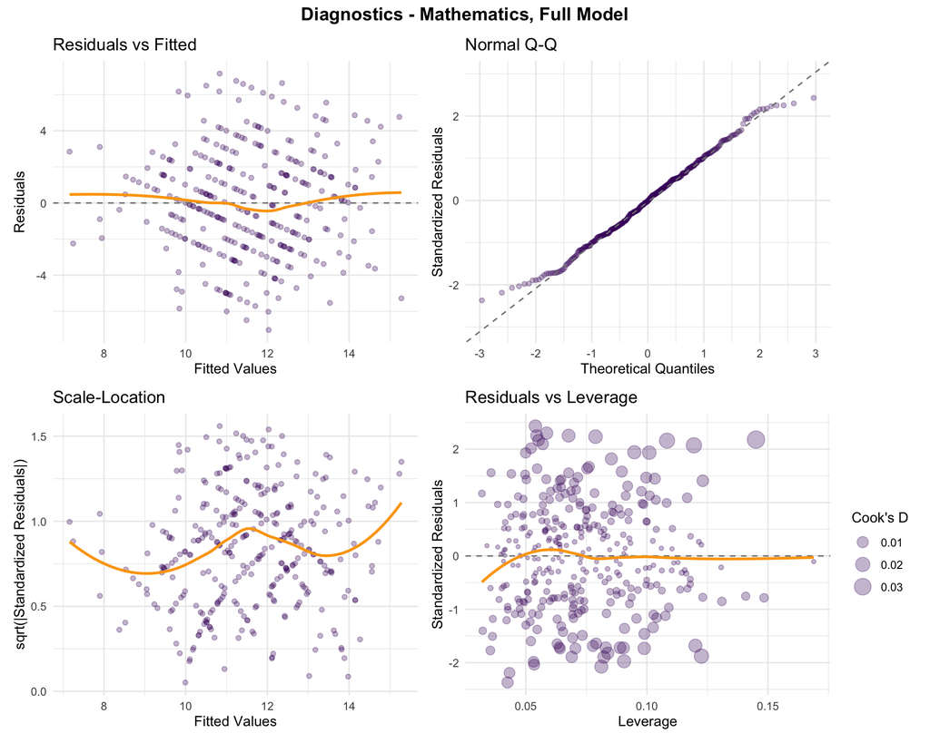

```r
make_diag_plots(mod_mat_full, "Diagnostics - Mathematics, Full Model")
```

#### Portuguese - Full Model

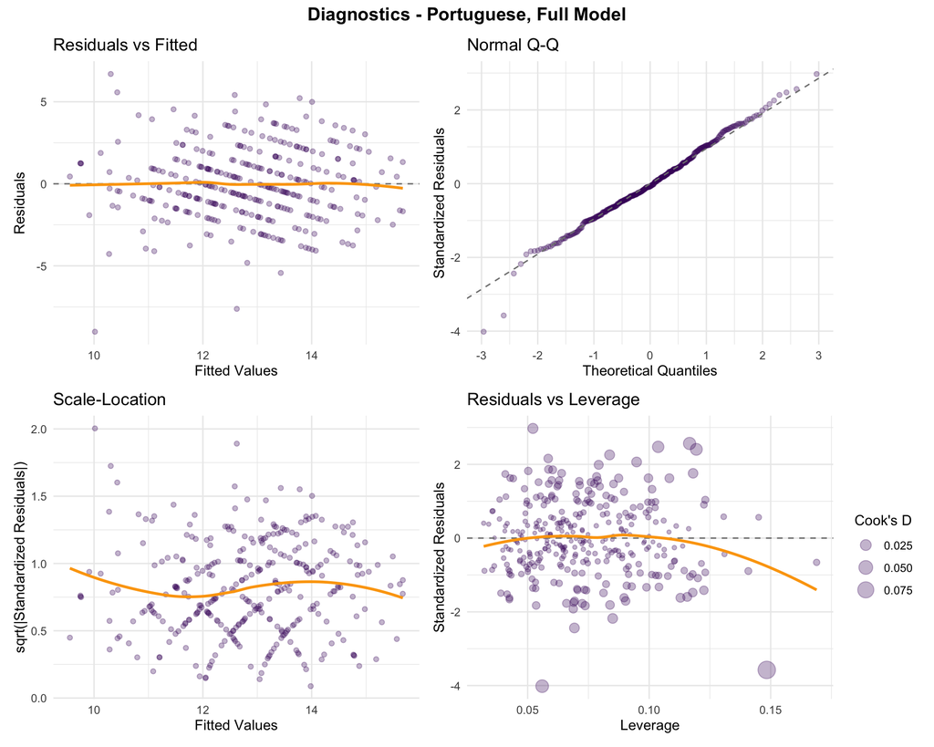

```r
make_diag_plots(mod_por_full, "Diagnostics - Portuguese, Full Model")
```